# KaizoIronmon

Celine Mangahas

2024-04-16

## Introduction

Pokemon has been one of the most popular games for the last 28 years. However, some players have agreed the recent games have dropped in difficulty; they needed a new challenge, a better twist on their favorite game series. Iateyourpie created a Pokemon Randomizer that randomizes Pokemon spawns, stats, items, even abilities to push players to the limit: The IronMON Challenge. One of the most famous versions of the IronMON Challenge is Kaizo IronMON—with 38 rules restricting the player on what items, Pokemon, moves and abilities one can use against harder, smarter AI. It’s no wonder the challenge has many losses and very, very few wins.

There are various analyses from the moderators and streamers that have taken on the challenge, however, using the R programming language could create a new perspective for all to see. Graphs such as the violin and dodge plots could be useful to see which are the most popular/used types for the challenge, and possibly using the package “tidyverse” for data visualization. I would also like to evaluate the relationship between abilities and Pokemon types to see how valuable typing and abilities are. I could also look at how certain stats could play into a gamer winning their challenge. I would have to webscrape the data borrowed from the IronMON community with permission.

## Graph/Visual Analysis of Kaizo Ironmon

Win status by Pokemon:

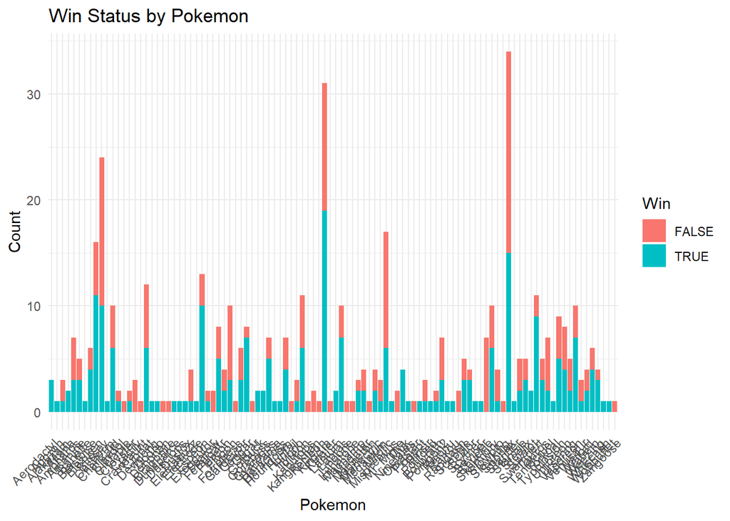

Facet grid of Type1 vs Special Attack color-organized by Win Status

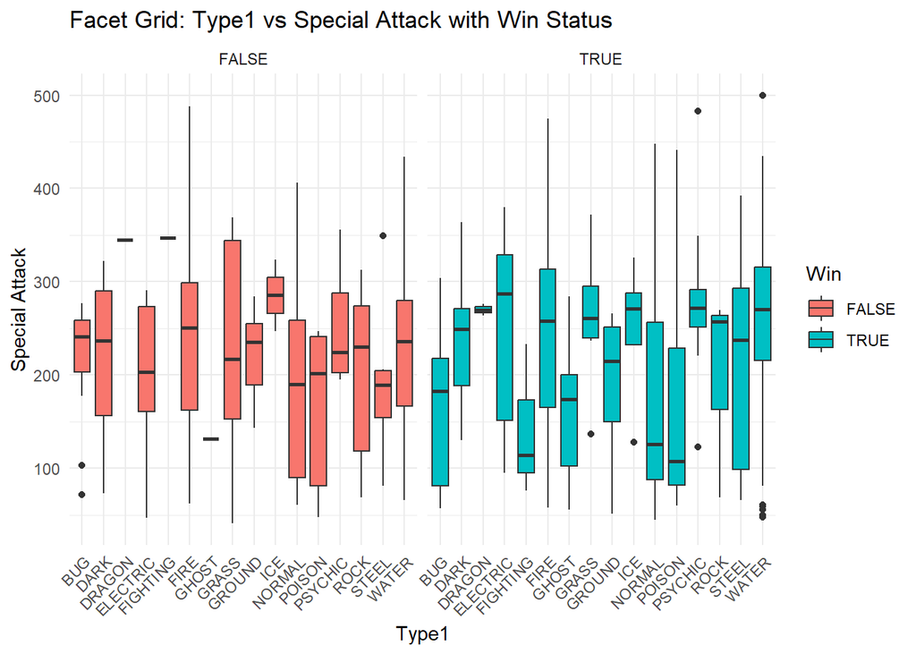

Box plot of Win statuses:

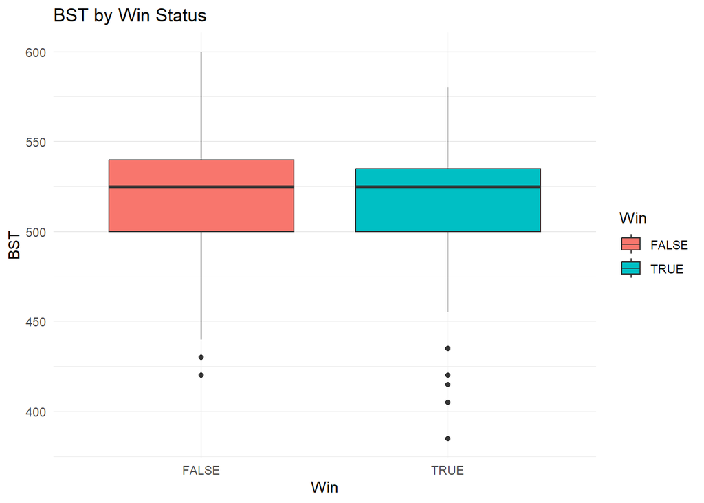

Scatter plot of Special attack vs. Defense. There is a smoothed line on the graph to represent a possible slope to show the relationship between special attack and defense, however, due to the random number generation (RNG for short in gamer terminology), there is no general relationship detected:

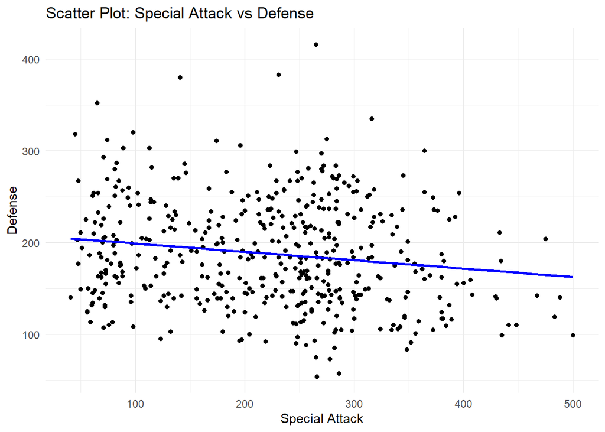

Filtered Data of Pokemon with BST under 500

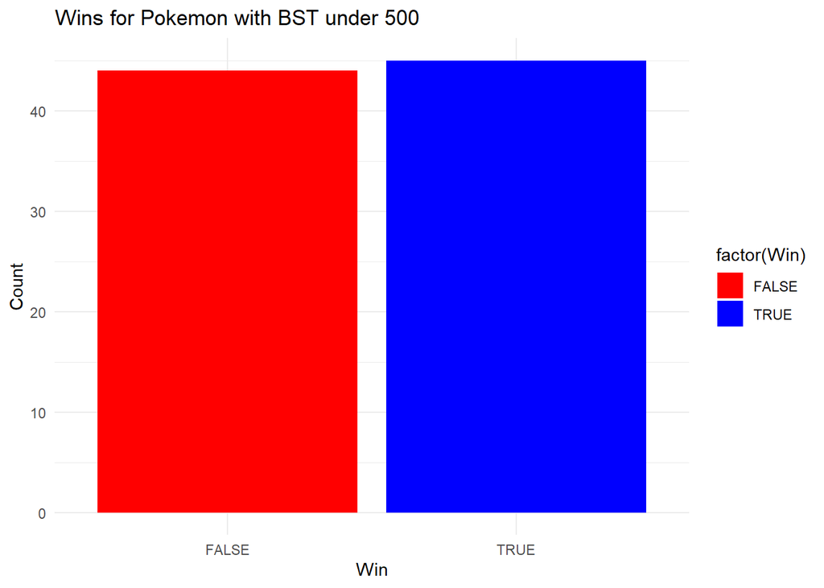

Filtered Data of Pokemon with BST under 450

```
##   Rank SubmissionDate        Runner   Pokemon   Type1  Type2 BST   Win Game
## 1  488      8/12/2022   joejoebeans    Gligar  GROUND FLYING 430 FALSE FRLG
## 2  442      8/27/2023      shiru666    Fearow  NORMAL FLYING 442 FALSE FRLG
## 3  483     10/13/2023        Nansey    Dustox     BUG POISON 385  TRUE FRLG
## 4  327       3/5/2024      Shiru666    Fearow  NORMAL FLYING 442 FALSE FRLG
## 5  444      8/21/2023 CptCuddlebuns   Kecleon  NORMAL    N/A 440 FALSE FRLG
## 6  401     10/13/2023        Nansey Wobbuffet PSYCHIC    N/A 405  TRUE FRLG
##   Elite4Level       Ability  Nature PokemonLvl  HP Attack Defense SpecialAttack
## 1          88        Static Careful         88 244    155     179           143
## 2          89  Water Absorb     Lax         89 217    249     352            65
## 3          91 Compound Eyes  Lonely         93 235    257     150            57
## 4          91    Swift Swim Careful         92 203    361     113            79
## 5          91        Stench Naughty         91 223    294     222            86
## 6          91  Serene Grace   Timid         93 216    108     252           263
##   SpecialDefense Speed        Move1         Move2        Move3       Move4   IV
## 1            209   156   Drill Peck       Sharpen   Earthquake Shadow Ball 18.1
## 2            140    92 Secret Power     Aeroblast Dragon Dance Odor Sleuth 15.0
## 3            124   234  Sludge Bomb  Swords Dance  Meteor Mash Lovely Kiss 17.3
## 4            132   223  Hyper Voice   Signal Beam Shadow Punch Double Kick 10.4
## 5            155   138    Body Slam  Dragon Dance  Sludge Bomb Silver Wind 13.1
## 6            148   136    Mist Ball Dragon Breath    Heat Wave Muddy Water 23.2
```

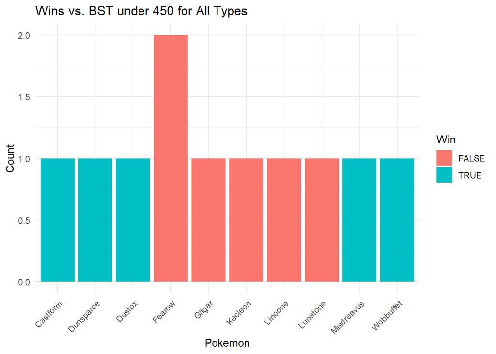

Bar chart of which types win the most. Water and normal types seem to win the most from my analyses.

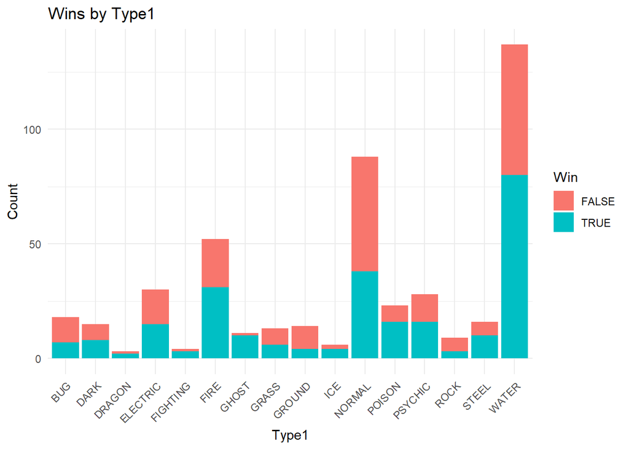

[figure not shown]

Stacked Bar chart of which types win the most. Water and normal types seem to win the most from my analyses.

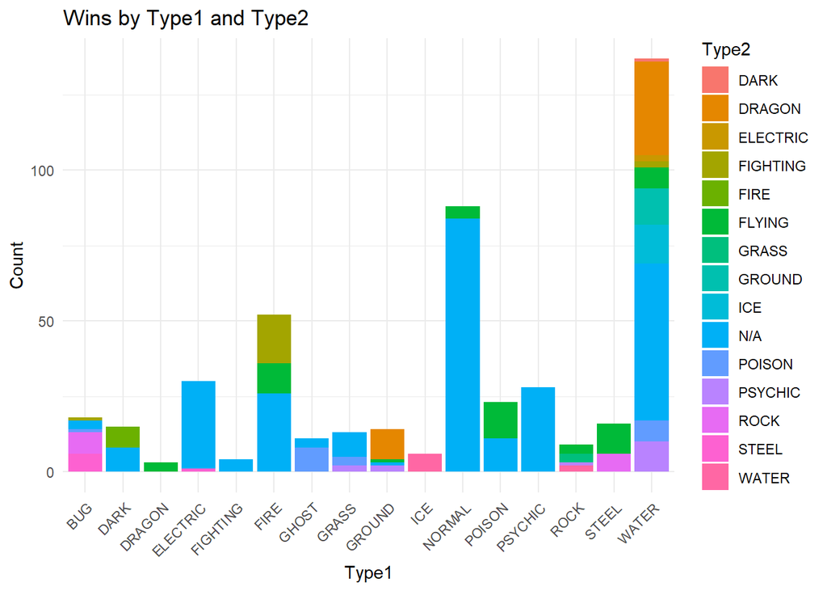

```
## # A tibble: 45 × 4
## # Groups:   Type1 [16]
##    Type1    Type2    TotalWins TotalLosses
##    <chr>    <chr>        <int>       <int>
##  1 BUG      FIGHTING         1           0
##  2 BUG      N/A              1           2
##  3 BUG      POISON           1           0
##  4 BUG      ROCK             0           7
##  5 BUG      STEEL            4           2
##  6 DARK     FIRE             4           3
##  7 DARK     N/A              4           4
##  8 DRAGON   FLYING           2           1
##  9 ELECTRIC N/A             15          14
## 10 ELECTRIC STEEL            0           1
## # ℹ 35 more rows
```

## Numerical Analysis of Ironmon

To determine whether or not the data fits a normal distribution (data is symmetric to the mean, showing data near the mean to be more frequent closer than farther), I used the Shapiro-Wilk test to find the p-value of the following values: IV, HP, Speed, Special Defense, Special Attack, Attack, Base Stat, Level, and Defense.

Let H0, our null hypothesis, be each value follow a Normal distribution Let Ha, the alternative hypothesis, - each of the values does not follow a Normal distribution

```
##
##  Shapiro-Wilk normality test
##
## data:  ironmon$IV
## W = 0.99498, p-value = 0.1343
```

```
##
##  Shapiro-Wilk normality test
##
## data:  ironmon$Speed
## W = 0.9984, p-value = 0.9483
```

```
##
##  Shapiro-Wilk normality test
##
## data:  ironmon$Attack
## W = 0.93569, p-value = 2.598e-13
```

```
##
##  Shapiro-Wilk normality test
##
## data:  ironmon$Defense
## W = 0.98221, p-value = 1.736e-05
```

```
##
##  Shapiro-Wilk normality test
##
## data:  ironmon$HP
## W = 0.98678, p-value = 0.0003036
```

```
##
##  Shapiro-Wilk normality test
##
## data:  ironmon$SpecialDefense
## W = 0.99342, p-value = 0.03957
```

```
##
##  Shapiro-Wilk normality test
##
## data:  ironmon$SpecialAttack
## W = 0.9714, p-value = 6.542e-08
```

```
##
##  Shapiro-Wilk normality test
##
## data:  ironmon$PokemonLvl
## W = 0.97556, p-value = 4.747e-07
```

```
##
##  Shapiro-Wilk normality test
##
## data:  ironmon$BST
## W = 0.86338, p-value < 2.2e-16
```

## Wins and Losses Analyses

Here is a calulation of wins and losses by types.

```
## # A tibble: 45 × 4
## # Groups:   Type1 [16]
##    Type1    Type2    TotalWins TotalLosses
##    <chr>    <chr>        <int>       <int>
##  1 BUG      FIGHTING         1           0
##  2 BUG      N/A              1           2
##  3 BUG      POISON           1           0
##  4 BUG      ROCK             0           7
##  5 BUG      STEEL            4           2
##  6 DARK     FIRE             4           3
##  7 DARK     N/A              4           4
##  8 DRAGON   FLYING           2           1
##  9 ELECTRIC N/A             15          14
## 10 ELECTRIC STEEL            0           1
## # ℹ 35 more rows
```

```
## Type1 and Type2 with the most wins:
```

```
## # A tibble: 17 × 4
## # Groups:   Type1 [16]
##    Type1    Type2  TotalWins TotalLosses
##    <chr>    <chr>      <int>       <int>
##  1 BUG      STEEL          4           2
##  2 DARK     FIRE           4           3
##  3 DARK     N/A            4           4
##  4 DRAGON   FLYING         2           1
##  5 ELECTRIC N/A           15          14
##  6 FIGHTING N/A            3           1
##  7 FIRE     N/A           14          12
##  8 GHOST    POISON         7           1
##  9 GRASS    N/A            4           4
## 10 GROUND   DRAGON         3           7
## 11 ICE      WATER          4           2
## 12 NORMAL   N/A           36          48
## 13 POISON   N/A           10           1
## 14 PSYCHIC  N/A           16          12
## 15 ROCK     FLYING         3           0
## 16 STEEL    FLYING         6           4
## 17 WATER    N/A           29          23
```

```
##
## Type1 and Type2 with the most losses:
```

```
## # A tibble: 16 × 4
## # Groups:   Type1 [16]
##    Type1    Type2  TotalWins TotalLosses
##    <chr>    <chr>      <int>       <int>
##  1 BUG      ROCK           0           7
##  2 DARK     N/A            4           4
##  3 DRAGON   FLYING         2           1
##  4 ELECTRIC N/A           15          14
##  5 FIGHTING N/A            3           1
##  6 FIRE     N/A           14          12
##  7 GHOST    POISON         7           1
##  8 GRASS    N/A            4           4
##  9 GROUND   DRAGON         3           7
## 10 ICE      WATER          4           2
## 11 NORMAL   N/A           36          48
## 12 POISON   FLYING         6           6
## 13 PSYCHIC  N/A           16          12
## 14 ROCK     GRASS          0           3
## 15 STEEL    FLYING         6           4
## 16 WATER    N/A           29          23
```

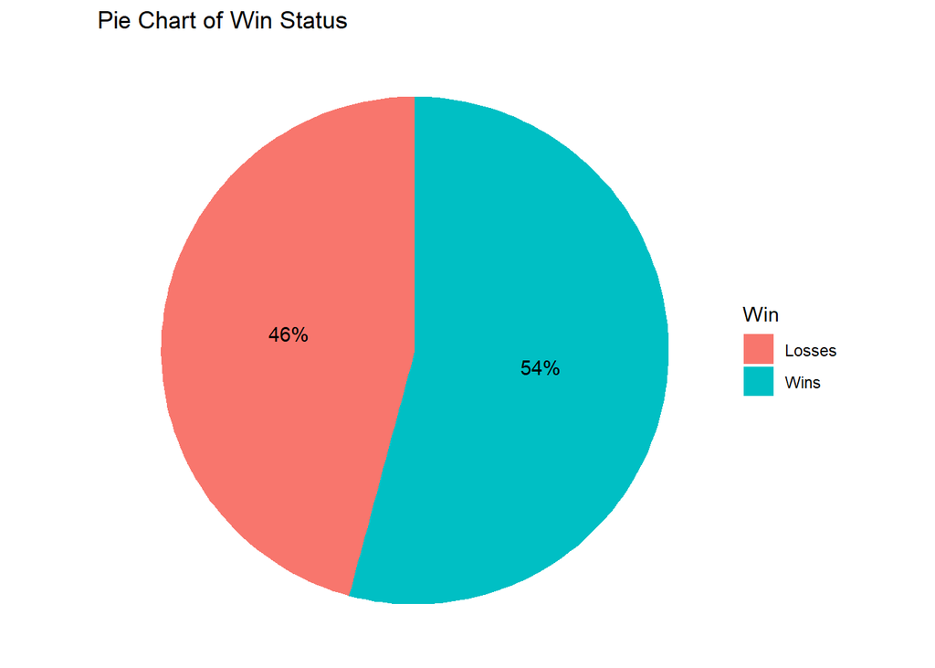

```
##       Type1  n
## 1     WATER 80
## 2    NORMAL 38
## 3      FIRE 31
## 4    POISON 16
## 5   PSYCHIC 16
## 6  ELECTRIC 15
## 7     GHOST 10
## 8     STEEL 10
## 9      DARK  8
## 10      BUG  7
## 11    GRASS  6
## 12   GROUND  4
## 13      ICE  4
## 14 FIGHTING  3
## 15     ROCK  3
## 16   DRAGON  2
```